# Correlaciones entre variables del Censo y CASEN a nivel de Zona Censal

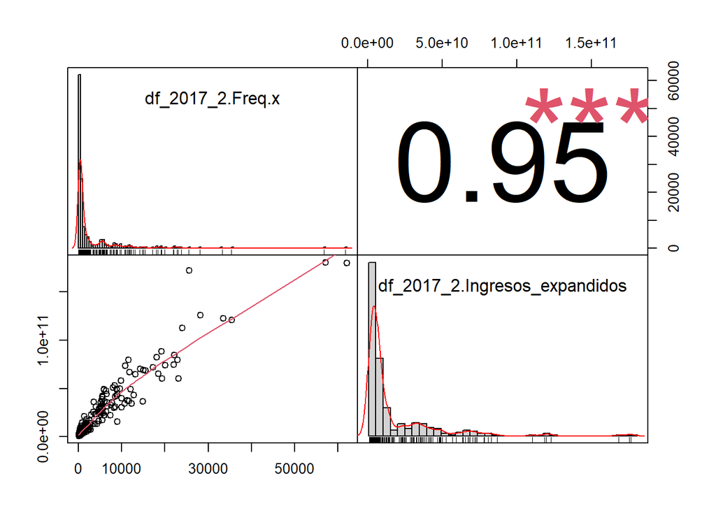

```r
dat1 <- data.frame(df_2017_2$Freq.x, df_2017_2$Ingresos_expandidos)
chart.Correlation(dat1)
```

2 Losa hormigón

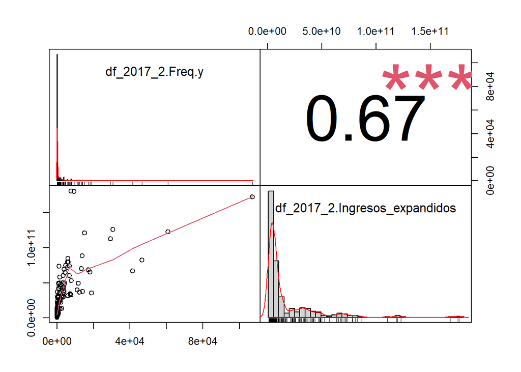

```r
dat1 <- data.frame(df_2017_2$Freq.y, df_2017_2$Ingresos_expandidos)
chart.Correlation(dat1)
```

3 Planchas metálicas de zinc, cobre, etc. o fibrocemento (tipo pizarreño)

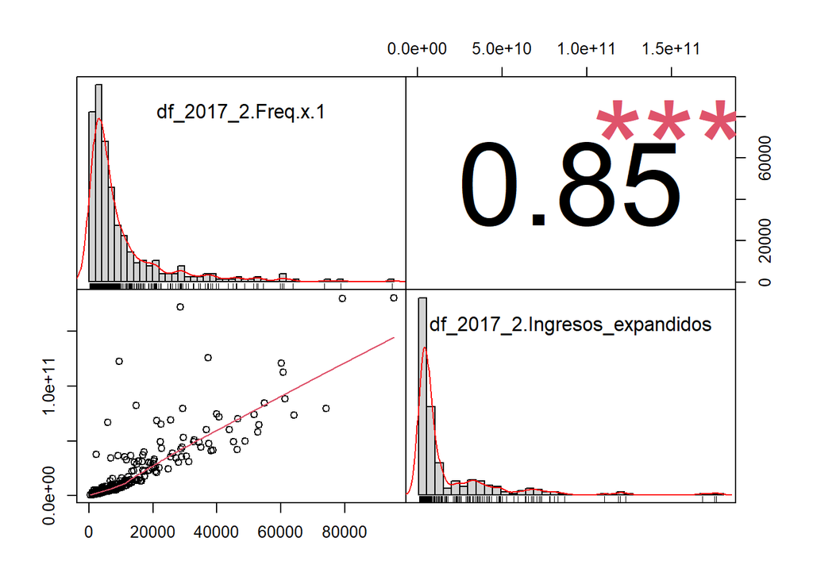

```r
dat1 <- data.frame(df_2017_2$Freq.x.1, df_2017_2$Ingresos_expandidos)
chart.Correlation(dat1)
```

4 Fonolita o plancha de fieltro embreado

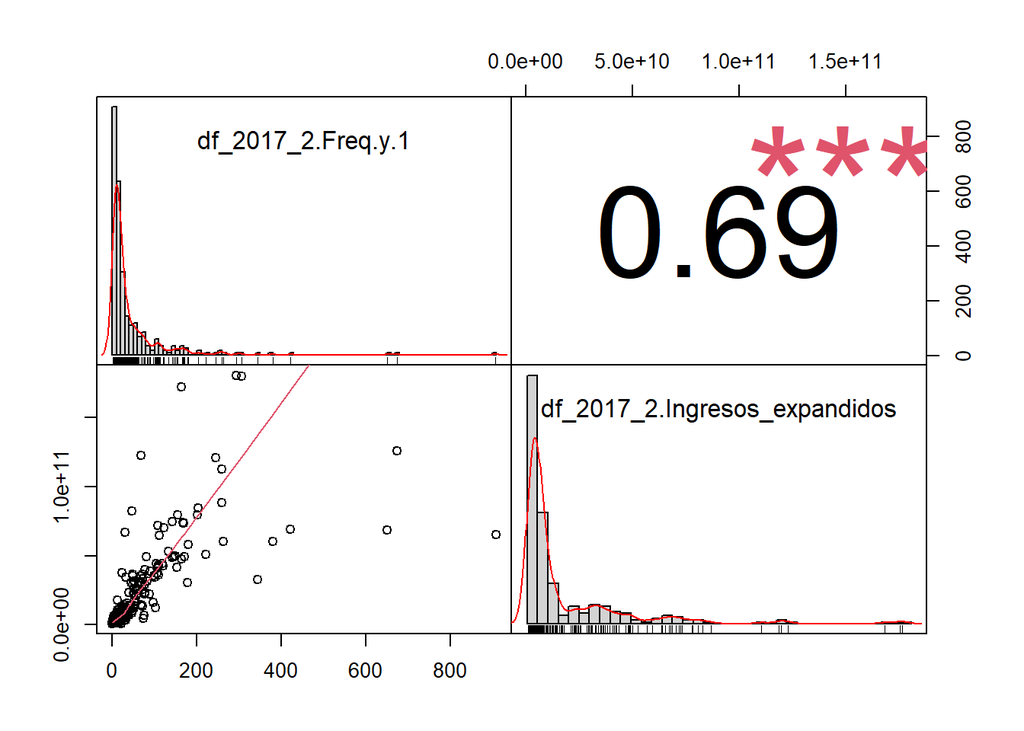

```r
dat1 <- data.frame(df_2017_2$Freq.y.1, df_2017_2$Ingresos_expandidos)
chart.Correlation(dat1)
```

5 Paja, coirón, totora o caña

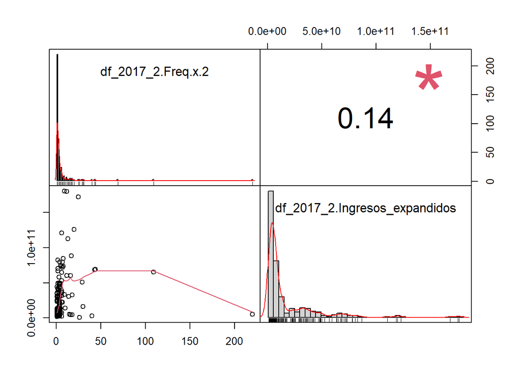

```r
dat1 <- data.frame(df_2017_2$Freq.x.2, df_2017_2$Ingresos_expandidos)
chart.Correlation(dat1)
```

6 Materiales precarios (lata, cartón, plásticos, etc.)

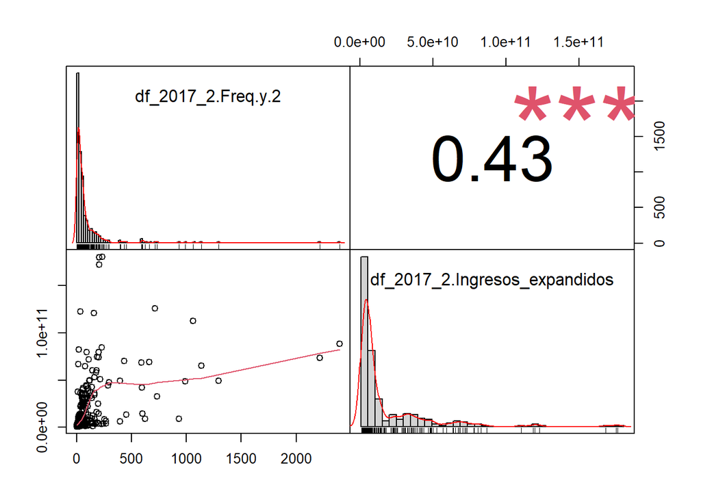

```r
dat1 <- data.frame(df_2017_2$Freq.y.2, df_2017_2$Ingresos_expandidos)
chart.Correlation(dat1)
```

7 Sin cubierta sólida de techo

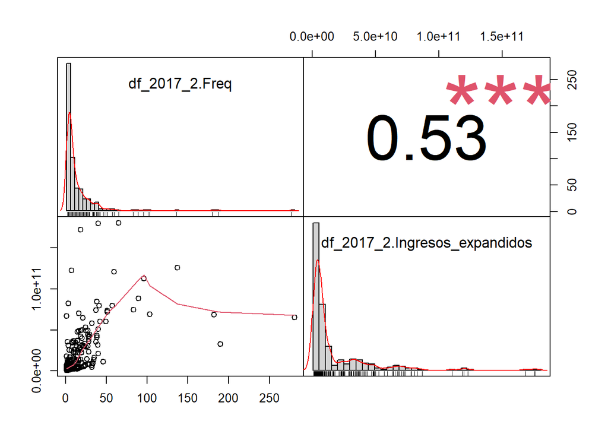

```r
dat1 <- data.frame(df_2017_2$Freq, df_2017_2$Ingresos_expandidos)
chart.Correlation(dat1)
```

## 2 Cálculo de correlaciones entre la frecuencia de la variable por población y los ingresos expandidos

### 2.1 **P03B**: Material en la cubierta del techo

Verifiquemos que nuestra tabla a correlacionar sea la correcta:

```r
tablamadre <- head(df_2017_2,50)
kbl(tablamadre) %>%
  kable_styling(bootstrap_options = c("striped", "hover")) %>%
  kable_paper() %>%
  scroll_box(width = "100%", height = "300px")
```

| código | unlist.c..x | Freq.x | anio.x | unlist.c..y | Freq.y | anio.y | unlist.c..x.1 | Freq.x.1 | anio.x.1 | unlist.c..y.1 | Freq.y.1 | anio.y.1 | unlist.c..x.2 | Freq.x.2 | anio.x.2 | unlist.c..y.2 | Freq.y.2 | anio.y.2 | unlist.c. | Freq | anio | comuna.x | promedio_i | año | comuna.y | personas | Ingresos_expandidos | tipo |
| --- | --- | --- | --- | --- | --- | --- | --- | --- | --- | --- | --- | --- | --- | --- | --- | --- | --- | --- | --- | --- | --- | --- | --- | --- | --- | --- | --- | --- |
| 01101 | 1 | 15518 | 2017 | 2 | 17268 | 2017 | 3 | 21126 | 2017 | 4 | 651 | 2017 | 5 | 43 | 2017 | 6 | 590 | 2017 | 7 | 182 | 2017 | Iquique | 356487.6 | 2017 | 1101 | 191468 | 68255976664 | Urbano |
| 01107 | 1 | 7463 | 2017 | 2 | 7673 | 2017 | 3 | 11776 | 2017 | 4 | 344 | 2017 | 5 | 18 | 2017 | 6 | 733 | 2017 | 7 | 190 | 2017 | Alto Hospicio | 301933.4 | 2017 | 1107 | 108375 | 32722034397 | Urbano |
| 01401 | 1 | 933 | 2017 | 2 | 112 | 2017 | 3 | 2762 | 2017 | 4 | 75 | 2017 | 5 | 18 | 2017 | 6 | 124 | 2017 | 7 | 32 | 2017 | Pozo Almonte | 299998.6 | 2017 | 1401 | 15711 | 4713278189 | Urbano |
| 01402 | 1 | 82 | 2017 | 2 | 6 | 2017 | 3 | 369 | 2017 | 4 | 5 | 2017 | 5 | 1 | 2017 | 6 | 3 | 2017 | 7 | 1 | 2017 | NA | NA | NA | NA | NA | NA | NA |
| 01403 | 1 | 41 | 2017 | 2 | 3 | 2017 | 3 | 344 | 2017 | 4 | 2 | 2017 | 5 | 69 | 2017 | 6 | 3 | 2017 | NA | NA | NA | NA | NA | NA | NA | NA | NA | NA |
| 01404 | 1 | 205 | 2017 | 2 | 13 | 2017 | 3 | 620 | 2017 | 4 | 20 | 2017 | 5 | 9 | 2017 | 6 | 62 | 2017 | 7 | 8 | 2017 | NA | NA | NA | NA | NA | NA | NA |
| 01405 | 1 | 368 | 2017 | 2 | 42 | 2017 | 3 | 1085 | 2017 | 4 | 20 | 2017 | 5 | 40 | 2017 | 6 | 36 | 2017 | 7 | 2 | 2017 | Pica | 330061.1 | 2017 | 1405 | 9296 | 3068247619 | Urbano |
| 02101 | 1 | 28222 | 2017 | 2 | 30665 | 2017 | 3 | 37231 | 2017 | 4 | 674 | 2017 | 5 | 20 | 2017 | 6 | 715 | 2017 | 7 | 137 | 2017 | Antofagasta | 347580.2 | 2017 | 2101 | 361873 | 125779893517 | Urbano |
| 02102 | 1 | 753 | 2017 | 2 | 599 | 2017 | 3 | 1602 | 2017 | 4 | 33 | 2017 | 5 | 1 | 2017 | 6 | 34 | 2017 | 7 | 7 | 2017 | Mejillones | 369770.7 | 2017 | 2102 | 13467 | 4979702302 | Urbano |
| 02103 | 1 | 48 | 2017 | 2 | 5 | 2017 | 3 | 285 | 2017 | 4 | 1 | 2017 | NA | NA | NA | 6 | 1 | 2017 | NA | NA | NA | NA | NA | NA | NA | NA | NA | NA |
| 02104 | 1 | 701 | 2017 | 2 | 72 | 2017 | 3 | 2574 | 2017 | 4 | 18 | 2017 | NA | NA | NA | 6 | 66 | 2017 | 7 | 22 | 2017 | Taltal | 376328.9 | 2017 | 2104 | 13317 | 5011572025 | Urbano |
| 02201 | 1 | 15078 | 2017 | 2 | 3796 | 2017 | 3 | 25641 | 2017 | 4 | 422 | 2017 | 5 | 44 | 2017 | 6 | 661 | 2017 | 7 | 103 | 2017 | Calama | 416281.1 | 2017 | 2201 | 165731 | 68990679686 | Urbano |
| 02202 | 1 | 20 | 2017 | NA | NA | NA | 3 | 67 | 2017 | NA | NA | NA | 5 | 4 | 2017 | 6 | 3 | 2017 | NA | NA | NA | NA | NA | NA | NA | NA | NA | NA |
| 02203 | 1 | 424 | 2017 | 2 | 13 | 2017 | 3 | 2094 | 2017 | 4 | 33 | 2017 | 5 | 220 | 2017 | 6 | 54 | 2017 | 7 | 1 | 2017 | San Pedro de Atacama | 437934.7 | 2017 | 2203 | 10996 | 4815529626 | Urbano |
| 02301 | 1 | 2406 | 2017 | 2 | 906 | 2017 | 3 | 4218 | 2017 | 4 | 77 | 2017 | NA | NA | NA | 6 | 97 | 2017 | 7 | 32 | 2017 | Tocopilla | 271720.8 | 2017 | 2301 | 25186 | 6843559467 | Urbano |
| 02302 | 1 | 410 | 2017 | 2 | 4 | 2017 | 3 | 963 | 2017 | 4 | 2 | 2017 | 5 | 1 | 2017 | 6 | 23 | 2017 | 7 | 3 | 2017 | María Elena | 466266.9 | 2017 | 2302 | 6457 | 3010685220 | Urbano |
| 03101 | 1 | 8019 | 2017 | 2 | 3664 | 2017 | 3 | 32996 | 2017 | 4 | 222 | 2017 | 5 | 29 | 2017 | 6 | 216 | 2017 | 7 | 40 | 2017 | Copiapó | 330574.6 | 2017 | 3101 | 153937 | 50887663717 | Urbano |
| 03102 | 1 | 1014 | 2017 | 2 | 79 | 2017 | 3 | 4371 | 2017 | 4 | 32 | 2017 | 5 | 15 | 2017 | 6 | 52 | 2017 | 7 | 16 | 2017 | Caldera | 299314.8 | 2017 | 3102 | 17662 | 5286498241 | Urbano |
| 03103 | 1 | 239 | 2017 | 2 | 5 | 2017 | 3 | 3488 | 2017 | 4 | 12 | 2017 | 5 | 16 | 2017 | 6 | 13 | 2017 | 7 | 5 | 2017 | Tierra Amarilla | 315860.6 | 2017 | 3103 | 14019 | 4428049932 | Urbano |
| 03201 | 1 | 229 | 2017 | 2 | 71 | 2017 | 3 | 3267 | 2017 | 4 | 31 | 2017 | 5 | 3 | 2017 | 6 | 59 | 2017 | 7 | 5 | 2017 | Chañaral | 286389.3 | 2017 | 3201 | 12219 | 3499391196 | Urbano |
| 03202 | 1 | 646 | 2017 | 2 | 670 | 2017 | 3 | 3111 | 2017 | 4 | 5 | 2017 | 5 | 1 | 2017 | 6 | 29 | 2017 | 7 | 5 | 2017 | Diego de Almagro | 325861.5 | 2017 | 3202 | 13925 | 4537621312 | Urbano |
| 03301 | 1 | 4699 | 2017 | 2 | 318 | 2017 | 3 | 10268 | 2017 | 4 | 98 | 2017 | 5 | 30 | 2017 | 6 | 181 | 2017 | 7 | 35 | 2017 | Vallenar | 311577.0 | 2017 | 3301 | 51917 | 16176145007 | Urbano |
| 03302 | 1 | 214 | 2017 | 2 | 1 | 2017 | 3 | 1445 | 2017 | 4 | 13 | 2017 | 5 | 31 | 2017 | 6 | 27 | 2017 | 7 | 7 | 2017 | NA | NA | NA | NA | NA | NA | NA |
| 03303 | 1 | 315 | 2017 | 2 | 3 | 2017 | 3 | 1886 | 2017 | 4 | 8 | 2017 | 5 | 2 | 2017 | 6 | 23 | 2017 | 7 | 3 | 2017 | Freirina | 289049.9 | 2017 | 3303 | 7041 | 2035200054 | Urbano |
| 03304 | 1 | 531 | 2017 | 2 | 48 | 2017 | 3 | 2640 | 2017 | 4 | 33 | 2017 | 5 | 1 | 2017 | 6 | 48 | 2017 | 7 | 7 | 2017 | Huasco | 337414.8 | 2017 | 3304 | 10149 | 3424422750 | Urbano |
| 04101 | 1 | 23191 | 2017 | 2 | 6839 | 2017 | 3 | 36623 | 2017 | 4 | 264 | 2017 | 5 | 12 | 2017 | 6 | 143 | 2017 | 7 | 42 | 2017 | La Serena | 272136.8 | 2017 | 4101 | 221054 | 60156924947 | Urbano |
| 04102 | 1 | 19353 | 2017 | 2 | 3376 | 2017 | 3 | 43825 | 2017 | 4 | 380 | 2017 | 5 | 16 | 2017 | 6 | 180 | 2017 | 7 | 49 | 2017 | Coquimbo | 264340.0 | 2017 | 4102 | 227730 | 60198159091 | Urbano |
| 04103 | 1 | 420 | 2017 | 2 | 2 | 2017 | 3 | 2980 | 2017 | 4 | 29 | 2017 | 5 | 1 | 2017 | 6 | 10 | 2017 | 7 | 5 | 2017 | Andacollo | 251267.7 | 2017 | 4103 | 11044 | 2775000288 | Urbano |
| 04104 | 1 | 163 | 2017 | NA | NA | NA | 3 | 1238 | 2017 | 4 | 23 | 2017 | NA | NA | NA | 6 | 25 | 2017 | 7 | 3 | 2017 | La Higuera | 214257.0 | 2017 | 4104 | 4241 | 908664019 | Urbano |
| 04105 | 1 | 146 | 2017 | 2 | 1 | 2017 | 3 | 1424 | 2017 | 4 | 4 | 2017 | 5 | 2 | 2017 | 6 | 8 | 2017 | 7 | 4 | 2017 | NA | NA | NA | NA | NA | NA | NA |
| 04106 | 1 | 981 | 2017 | 2 | 26 | 2017 | 3 | 7609 | 2017 | 4 | 27 | 2017 | 5 | 4 | 2017 | 6 | 37 | 2017 | 7 | 9 | 2017 | Vicuña | 245957.4 | 2017 | 4106 | 27771 | 6830481918 | Urbano |
| 04201 | 1 | 696 | 2017 | 2 | 75 | 2017 | 3 | 9311 | 2017 | 4 | 20 | 2017 | NA | NA | NA | 6 | 18 | 2017 | 7 | 5 | 2017 | Illapel | 270316.5 | 2017 | 4201 | 30848 | 8338722128 | Urbano |
| 04202 | 1 | 122 | 2017 | 2 | 4 | 2017 | 3 | 3223 | 2017 | 4 | 6 | 2017 | 5 | 6 | 2017 | 6 | 6 | 2017 | 7 | 9 | 2017 | Canela | 233397.3 | 2017 | 4202 | 9093 | 2122281844 | Urbano |
| 04203 | 1 | 945 | 2017 | 2 | 14 | 2017 | 3 | 6188 | 2017 | 4 | 25 | 2017 | 5 | 2 | 2017 | 6 | 11 | 2017 | 7 | 2 | 2017 | Los Vilos | 282415.6 | 2017 | 4203 | 21382 | 6038609501 | Urbano |
| 04204 | 1 | 775 | 2017 | 2 | 96 | 2017 | 3 | 7732 | 2017 | 4 | 18 | 2017 | 5 | 2 | 2017 | 6 | 24 | 2017 | 7 | 8 | 2017 | Salamanca | 262056.9 | 2017 | 4204 | 29347 | 7690585032 | Urbano |
| 04301 | 1 | 5460 | 2017 | 2 | 755 | 2017 | 3 | 27922 | 2017 | 4 | 179 | 2017 | 5 | 14 | 2017 | 6 | 105 | 2017 | 7 | 22 | 2017 | Ovalle | 274771.4 | 2017 | 4301 | 111272 | 30574361012 | Urbano |
| 04302 | 1 | 217 | 2017 | 2 | 2 | 2017 | 3 | 4603 | 2017 | 4 | 7 | 2017 | 5 | 3 | 2017 | 6 | 12 | 2017 | 7 | 9 | 2017 | Combarbalá | 228990.4 | 2017 | 4302 | 13322 | 3050610572 | Urbano |
| 04303 | 1 | 586 | 2017 | 2 | 14 | 2017 | 3 | 9507 | 2017 | 4 | 29 | 2017 | 5 | 2 | 2017 | 6 | 35 | 2017 | 7 | 5 | 2017 | Monte Patria | 225369.1 | 2017 | 4303 | 30751 | 6930326684 | Urbano |
| 04304 | 1 | 213 | 2017 | 2 | 6 | 2017 | 3 | 3471 | 2017 | 4 | 9 | 2017 | 5 | 1 | 2017 | 6 | 25 | 2017 | 7 | 4 | 2017 | Punitaqui | 212496.1 | 2017 | 4304 | 10956 | 2328107498 | Urbano |
| 04305 | 1 | 108 | 2017 | NA | NA | NA | 3 | 1529 | 2017 | 4 | 4 | 2017 | 5 | 1 | 2017 | 6 | 30 | 2017 | NA | NA | NA | NA | NA | NA | NA | NA | NA | NA |
| 05101 | 1 | 19178 | 2017 | 2 | 13731 | 2017 | 3 | 61208 | 2017 | 4 | 259 | 2017 | 5 | 17 | 2017 | 6 | 2398 | 2017 | 7 | 89 | 2017 | Valparaíso | 297929.0 | 2017 | 5101 | 296655 | 88382118059 | Urbano |
| 05102 | 1 | 1525 | 2017 | 2 | 350 | 2017 | 3 | 6690 | 2017 | 4 | 31 | 2017 | NA | NA | NA | 6 | 50 | 2017 | 7 | 7 | 2017 | Casablanca | 341641.8 | 2017 | 5102 | 26867 | 9178890241 | Urbano |
| 05103 | 1 | 4320 | 2017 | 2 | 2589 | 2017 | 3 | 6576 | 2017 | 4 | 72 | 2017 | 5 | 2 | 2017 | 6 | 52 | 2017 | 7 | 4 | 2017 | Concón | 318496.3 | 2017 | 5103 | 42152 | 13425257057 | Urbano |
| 05104 | 1 | 45 | 2017 | NA | NA | NA | 3 | 302 | 2017 | NA | NA | NA | NA | NA | NA | 6 | 1 | 2017 | NA | NA | NA | NA | NA | NA | NA | NA | NA | NA |
| 05105 | 1 | 1369 | 2017 | 2 | 56 | 2017 | 3 | 4850 | 2017 | 4 | 35 | 2017 | 5 | 3 | 2017 | 6 | 23 | 2017 | 7 | 8 | 2017 | Puchuncaví | 296035.5 | 2017 | 5105 | 18546 | 5490274928 | Urbano |
| 05107 | 1 | 2717 | 2017 | 2 | 503 | 2017 | 3 | 6985 | 2017 | 4 | 49 | 2017 | 5 | 2 | 2017 | 6 | 53 | 2017 | 7 | 19 | 2017 | Quintero | 308224.7 | 2017 | 5107 | 31923 | 9839456903 | Urbano |
| 05109 | 1 | 23960 | 2017 | 2 | 29228 | 2017 | 3 | 60722 | 2017 | 4 | 259 | 2017 | 5 | 13 | 2017 | 6 | 1061 | 2017 | 7 | 96 | 2017 | Viña del Mar | 337006.1 | 2017 | 5109 | 334248 | 112643604611 | Urbano |
| 05201 | 1 | 245 | 2017 | 2 | 4 | 2017 | 3 | 2159 | 2017 | 4 | 7 | 2017 | NA | NA | NA | 6 | 15 | 2017 | 7 | 1 | 2017 | NA | NA | NA | NA | NA | NA | NA |
| 05301 | 1 | 5144 | 2017 | 2 | 1233 | 2017 | 3 | 13952 | 2017 | 4 | 51 | 2017 | 5 | 6 | 2017 | 6 | 56 | 2017 | 7 | 19 | 2017 | Los Andes | 339720.2 | 2017 | 5301 | 66708 | 22662055502 | Urbano |
| 05302 | 1 | 1013 | 2017 | 2 | 31 | 2017 | 3 | 3555 | 2017 | 4 | 23 | 2017 | NA | NA | NA | 6 | 14 | 2017 | 7 | 1 | 2017 | Calle Larga | 246387.3 | 2017 | 5302 | 14832 | 3654416747 | Urbano |

Correlacionamos entre:

$$\frac{Freq.x}{personas} \ e \ Ingresos\_expandidos$$

1 Tejas o tejuelas de arcilla, metálicas, de cemento, de madera, asfálticas o plásticas

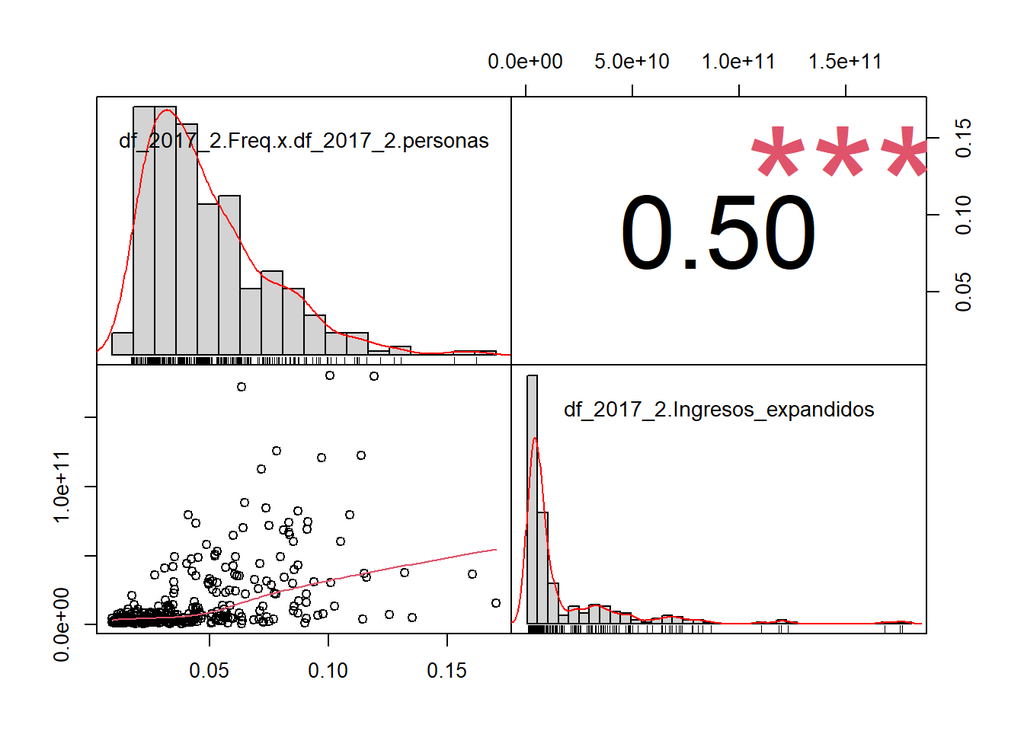

```r
dat1 <- data.frame(df_2017_2$Freq.x/df_2017_2$personas, df_2017_2$Ingresos_expandidos)
chart.Correlation(dat1)
```

2 Losa hormigón

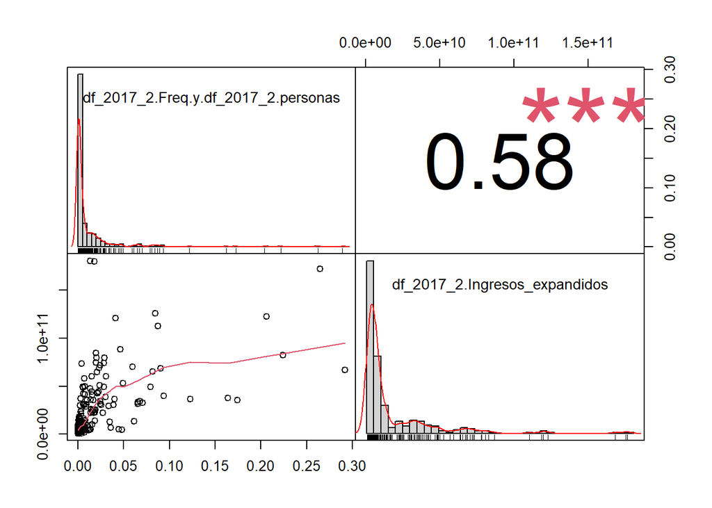

```r
dat1 <- data.frame(df_2017_2$Freq.y/df_2017_2$personas, df_2017_2$Ingresos_expandidos)
chart.Correlation(dat1)
```

3 Planchas metálicas de zinc, cobre, etc. o fibrocemento (tipo pizarreño)

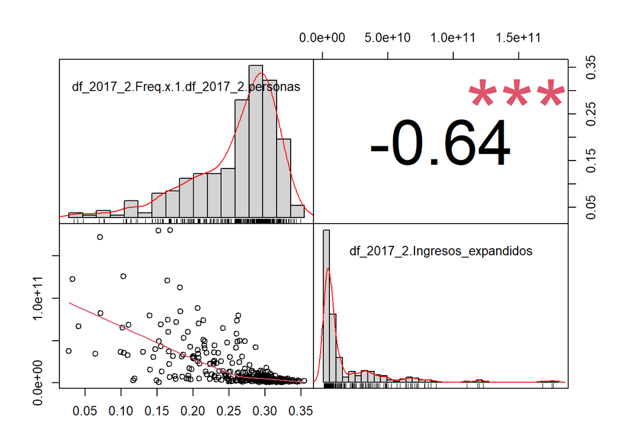

```r
dat1 <- data.frame(df_2017_2$Freq.x.1/df_2017_2$personas, df_2017_2$Ingresos_expandidos)
chart.Correlation(dat1)
```

4 Fonolita o plancha de fieltro embreado

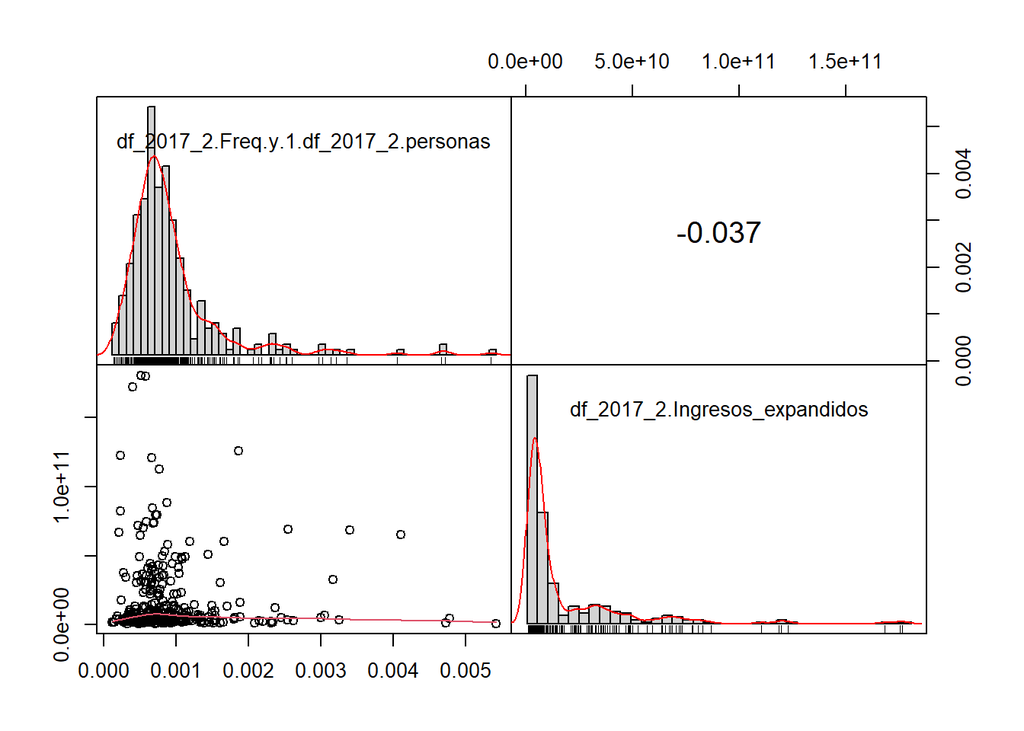

```r
dat1 <- data.frame(df_2017_2$Freq.y.1/df_2017_2$personas, df_2017_2$Ingresos_expandidos)
chart.Correlation(dat1)
```

5 Paja, coirón, totora o caña

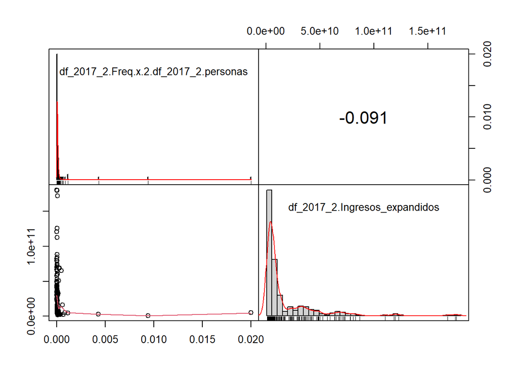

```r
dat1 <- data.frame(df_2017_2$Freq.x.2/df_2017_2$personas, df_2017_2$Ingresos_expandidos)
chart.Correlation(dat1)
```

6 Materiales precarios (lata, cartón, plásticos, etc.)

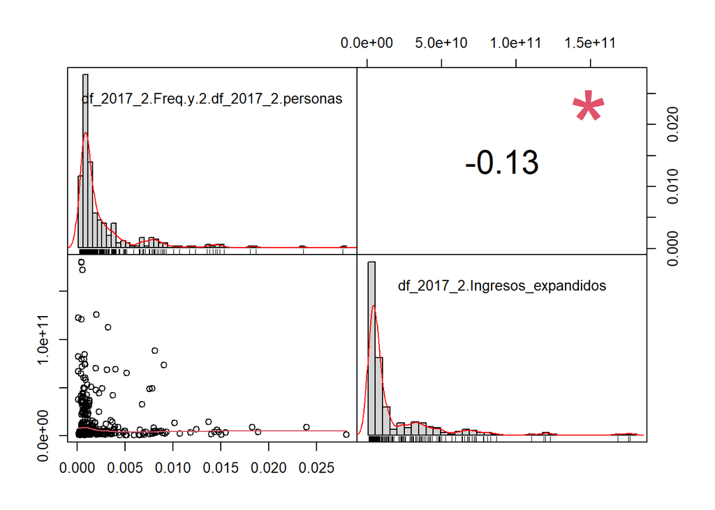

```r
dat1 <- data.frame(df_2017_2$Freq.y.2/df_2017_2$personas, df_2017_2$Ingresos_expandidos)
chart.Correlation(dat1)
```

7 Sin cubierta sólida de techo

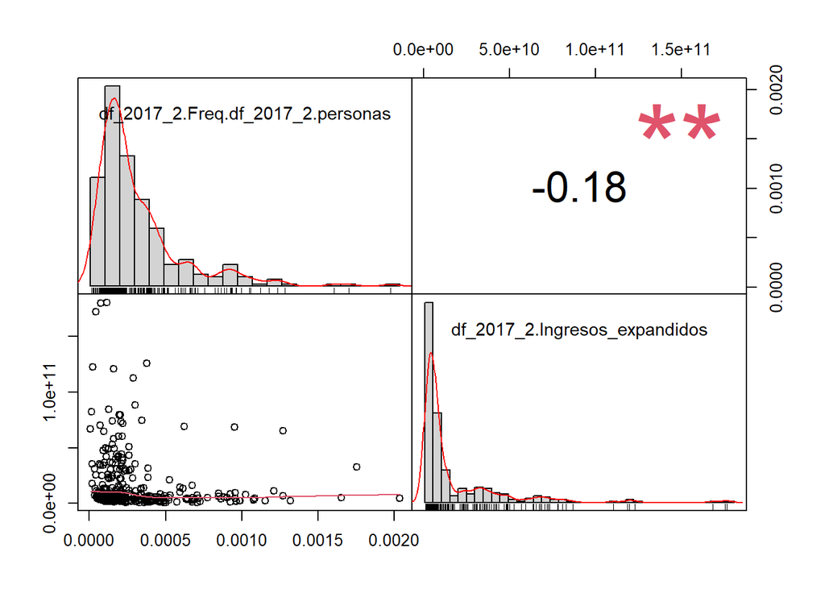

```r
dat1 <- data.frame(df_2017_2$Freq/df_2017_2$personas, df_2017_2$Ingresos_expandidos)
chart.Correlation(dat1)
```

## 3 Referencias

https://rpubs.com/osoramirez/316691

https://dataintelligencechile.shinyapps.io/casenfinal

Manual_de_usuario_Censo_2017_16R.pdf

http://www.censo2017.cl/microdatos/

Censo de Población y Vivienda

https://www.ine.cl/estadisticas/sociales/censos-de-poblacion-y-vivienda/poblacion-y-vivienda

https://rpubs.com/osoramirez/316691

https://dataintelligencechile.shinyapps.io/casenfinal